# world_happiness_project2

2023-10-26

After analyzing the happiness score in relation to some of the factors, I am curious how the countries compare by the factors individually. The first column I am going to compare is gdp per captita.

```r
gdppercapitadesc <- world_happinessv8 %>%
  group_by(country) %>%
  summarize(average_gdp = mean(gdp_per_capita)) %>%
  arrange(desc(average_gdp))

print(gdppercapitadesc)
```

```
## # A tibble: 168 × 2
##    country              average_gdp
##    <chr>                      <dbl>
##  1 Czechia                     1.82
##  2 Luxembourg                  1.77
##  3 Qatar                       1.74
##  4 Singapore                   1.72
##  5 United Arab Emirates        1.69
##  6 Ireland                     1.63
##  7 Norway                      1.62
##  8 Switzerland                 1.60
##  9 United States               1.57
## 10 Kuwait                      1.57
## # ℹ 158 more rows
```

```r
gdppercapitadesct12 <- gdppercapitadesc %>%
  slice_max(average_gdp, n = 12)

print(gdppercapitadesct12)
```

```
## # A tibble: 12 × 2
##    country                   average_gdp
##    <chr>                           <dbl>
##  1 Czechia                          1.82
##  2 Luxembourg                       1.77
##  3 Qatar                            1.74
##  4 Singapore                        1.72
##  5 United Arab Emirates             1.69
##  6 Ireland                          1.63
##  7 Norway                           1.62
##  8 Switzerland                      1.60
##  9 United States                    1.57
## 10 Kuwait                           1.57
## 11 Hong Kong S.A.R. of China        1.57
## 12 Netherlands                      1.53
```

Now I can visualize with ggplot…

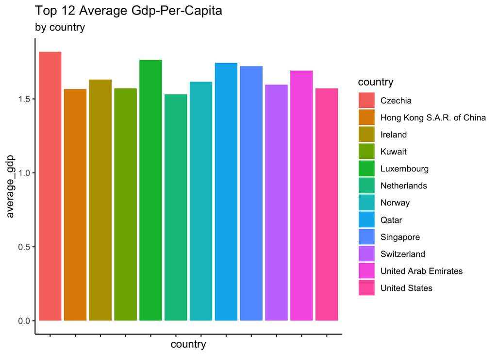

```r
topaveragegdpviz <- ggplot(gdppercapitadesct12, aes(country, average_gdp, fill = country))+
  geom_bar(stat = "identity")+
  theme_classic()+
  scale_x_discrete(guide = guide_axis(n.dodge = 2))+
  labs(title = "Top 12 Average Gdp-Per-Capita", subtitle = "by country")+
  theme(axis.text.x = element_blank())

print(topaveragegdpviz)
```

Now I’ll do the same for the social support column…

```r
socialsupportdesc <- world_happinessv8 %>%
  group_by(country) %>%
  summarize(average_social_support = mean(social_support))

socialsupportt12 <- socialsupportdesc %>%
  slice_max(average_social_support, n = 12)

print(socialsupportt12)
```

```
## # A tibble: 12 × 2
##    country      average_social_support
##    <chr>                         <dbl>
##  1 Iceland                        1.46
##  2 Denmark                        1.40
##  3 Finland                        1.40
##  4 Czechia                        1.40
##  5 New Zealand                    1.40
##  6 Norway                         1.39
##  7 Ireland                        1.38
##  8 Switzerland                    1.37
##  9 Australia                      1.37
## 10 Turkmenistan                   1.35
## 11 Spain                          1.35
## 12 Slovakia                       1.35
```

Now I will plot it…

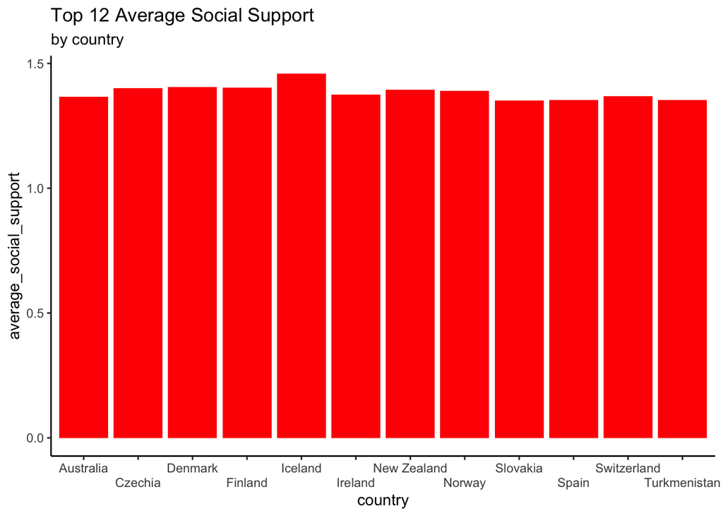

```r
socialsupportt12viz <- ggplot(socialsupportt12, aes(country, average_social_support))+
  geom_bar(stat = "identity", fill = "red")+
  theme_classic()+
  scale_x_discrete(guide = guide_axis(n.dodge = 2))+
  labs(title = "Top 12 Average Social Support", subtitle = "by country")

print(socialsupportt12viz)
```

From the ggpot visualize we can observe that Iceland has the highest social support score. The next column I am going to do is healthy life expectancy…

```r
lifeexpectancydesc <- world_happinessv8 %>%
  group_by(country) %>%
  summarize(average_life_expectancy = mean(healthy_life_expectancy)) %>%
  arrange(desc(average_life_expectancy))

lifeexpectancyt12 <- lifeexpectancydesc %>%
  slice_max(average_life_expectancy, n = 12)

print(lifeexpectancyt12)
```

```
## # A tibble: 12 × 2
##    country                   average_life_expectancy
##    <chr>                                       <dbl>
##  1 Hong Kong S.A.R. of China                   0.971
##  2 Singapore                                   0.952
##  3 Japan                                       0.922
##  4 South Korea                                 0.890
##  5 Spain                                       0.889
##  6 Cyprus                                      0.886
##  7 Switzerland                                 0.878
##  8 North Cyprus                                0.874
##  9 Italy                                       0.869
## 10 France                                      0.865
## 11 Iceland                                     0.858
## 12 Israel                                      0.856
```

Now the ggplot…

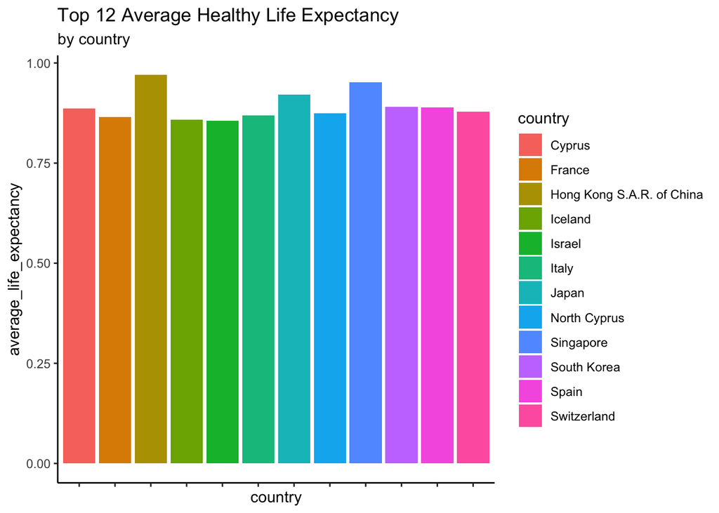

```r
lifeexpectancyt12viz <- ggplot(lifeexpectancyt12, aes(country, average_life_expectancy, fill = country))+
  geom_bar(stat = "identity")+
  theme_classic()+
  theme(axis.text.x = element_blank())+
  labs(title = "Top 12 Average Healthy Life Expectancy", subtitle = "by country")

print(lifeexpectancyt12viz)
```

When looking at the visualization, it’s clear that Hong Kong and Singapore scores highest with the average healthy life expectancies. The next column I will do is the freedom to make life choices column.

```r
freedomlifechoicesdesc <- world_happinessv8 %>%
  group_by(country) %>%
  summarize(average_freedom_to_make_life_choices = mean(freedom_to_make_life_choices)) %>%
  arrange(desc(average_freedom_to_make_life_choices))

freedomlifechoicest12 <- freedomlifechoicesdesc %>%
  slice_max(average_freedom_to_make_life_choices, n = 12)

print(freedomlifechoicest12)
```

```
## # A tibble: 12 × 2
##    country     average_freedom_to_make_life_choices
##    <chr>                                      <dbl>
##  1 Uzbekistan                                 0.683
##  2 Czechia                                    0.676
##  3 Cambodia                                   0.675
##  4 Norway                                     0.671
##  5 Finland                                    0.663
##  6 Denmark                                    0.659
##  7 Iceland                                    0.656
##  8 Sweden                                     0.656
##  9 New Zealand                                0.639
## 10 Switzerland                                0.638
## 11 Oman                                       0.633
## 12 Vietnam                                    0.629
```

Now to visualize…

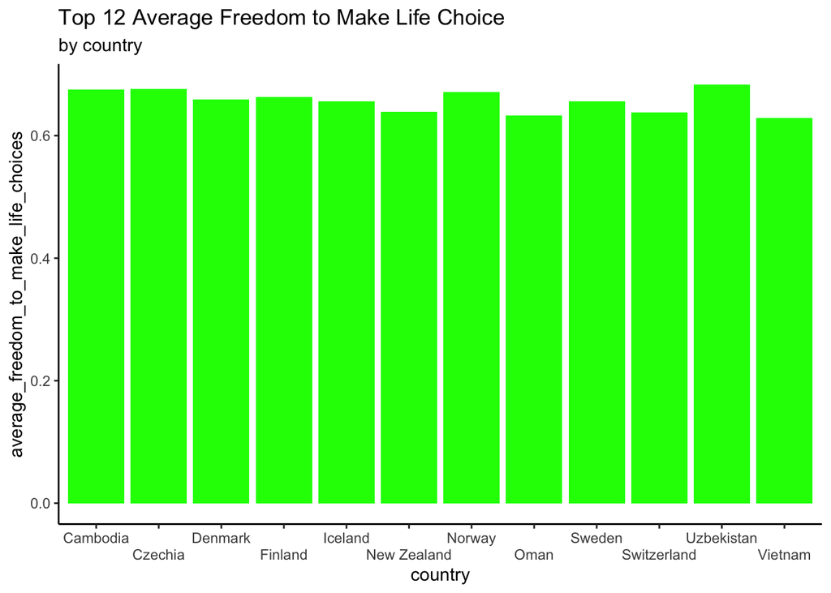

```r
freedomlifechoicest12viz <- ggplot(freedomlifechoicest12, aes(country, average_freedom_to_make_life_choices))+
  geom_bar(stat = "identity", fill = "green")+
  theme_classic()+
  scale_x_discrete(guide = guide_axis(n.dodge = 2))+
  labs(title = "Top 12 Average Freedom to Make Life Choice", subtitle = "by country")

print(freedomlifechoicest12viz)
```

From the visualization, Uzbekistan leads in the freedom to make life choices score. The next score I am going to look at is the generosity score. I will do as I did with the previous columns.

```r
generositydesc <- world_happinessv8 %>%
  group_by(country) %>%
  summarize(average_generosity = mean(generosity)) %>%
  arrange(desc(average_generosity))

generosityt12 <- generositydesc %>%
  slice_max(average_generosity, n = 12)

print(generosityt12)
```

```
## # A tibble: 12 × 2
##    country           average_generosity
##    <chr>                          <dbl>
##  1 Myanmar                        0.618
##  2 Indonesia                      0.516
##  3 Somaliland Region              0.509
##  4 Haiti                          0.453
##  5 Bhutan                         0.435
##  6 Syria                          0.431
##  7 Thailand                       0.425
##  8 United Kingdom                 0.378
##  9 Malta                          0.377
## 10 Gambia                         0.376
## 11 Kenya                          0.371
## 12 Iceland                        0.363
```

After arranging the average generosity in descending order and taking the top 12, Myanmar is the has the highest generosity score. This of course be better visualized with ggplot…

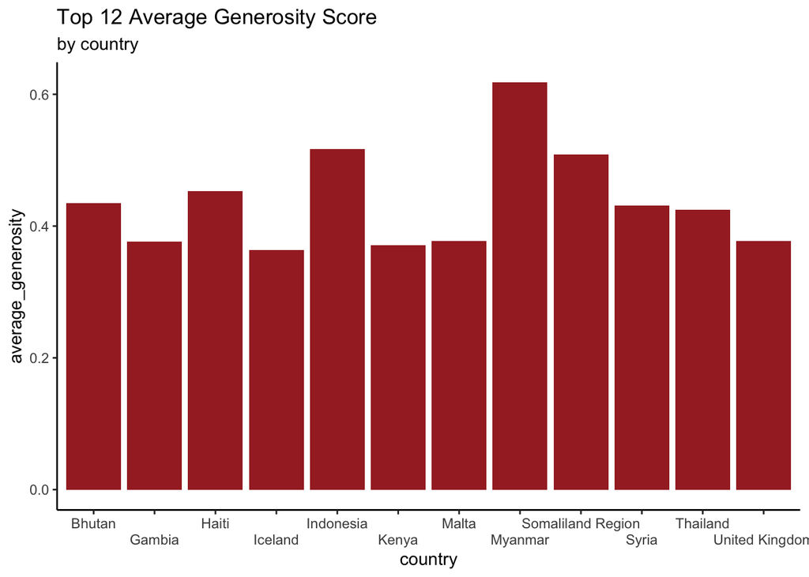

```r
generosityt12viz <- ggplot(generosityt12, aes(country, average_generosity))+
  geom_bar(stat = "identity", fill = "brown")+
  scale_x_discrete(guide = guide_axis(n.dodge = 2))+
  theme_classic()+
  labs(title = "Top 12 Average Generosity Score", subtitle = "by country")

print(generosityt12viz)
```

As you can see from the bar chart it clearly show’s Myanmar leading in the generosity category. Now I am going to check the last variable of this dataset, perceptions of corruption…

```r
perceptionsofcorruptiondesc <- world_happinessv8 %>%
  group_by(country) %>%
  summarize(average_perceptions_of_corruption = mean(perceptions_of_corruption)) %>%
  arrange(desc(average_perceptions_of_corruption))

perceptionsofcorruptiont12 <- perceptionsofcorruptiondesc %>%
  slice_max(average_perceptions_of_corruption, n = 12)

print(perceptionsofcorruptiont12)
```

```
## # A tibble: 12 × 2
##    country           average_perceptions_of_corruption
##    <chr>                                         <dbl>
##  1 Singapore                                     0.507
##  2 Rwanda                                        0.486
##  3 Denmark                                       0.465
##  4 Finland                                       0.447
##  5 Sweden                                        0.434
##  6 New Zealand                                   0.429
##  7 Switzerland                                   0.406
##  8 Norway                                        0.391
##  9 Somaliland Region                             0.384
## 10 Luxembourg                                    0.357
## 11 Qatar                                         0.356
## 12 Netherlands                                   0.340
```

After running that query, Singapore has the highest score in this category. Like I did with the other categories, I will now visualize this.

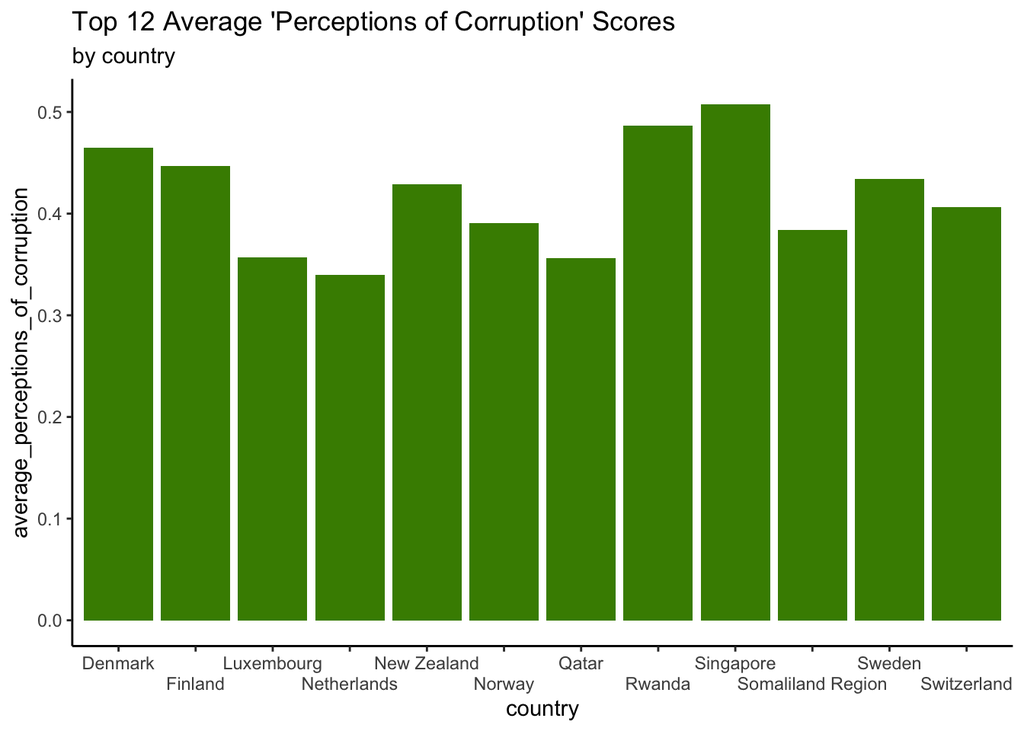

```r
perceptionsofcorruptiont12viz <- ggplot(perceptionsofcorruptiont12, aes(country, average_perceptions_of_corruption))+
  geom_bar(stat = "identity", fill = "chartreuse4")+
  scale_x_discrete(guide = guide_axis(n.dodge = 2))+
  theme_classic()+
  labs(title = "Top 12 Average 'Perceptions of Corruption' Scores", subtitle = "by country")

print(perceptionsofcorruptiont12viz)
```

As the chart clearly shows, Singapore leads in this category.

Well, that concludes my world_happiness project. Over the course of this project I cleaned and fixed several errors to make sure the data was ready for analysis. I then began analyzing where I found out many things, such as gdp per capita is the variable that positively correlates with the happiness score for dataset as a whole. Thanks for joining me, I hope to only improve as I continue these projects.